# Exporting sampled ancestor trees

Joelle Barido-Sottani

2023-10-05

## Zero-edge format

Many phylogenetic inference software packages, such as [BEAST2](http://www.beast2.org/) and [RevBayes](https://revbayes.github.io), can handle trees containing fossil samples. In the zero-edge format, tip samples are represented normally in the tree, but sampled ancestors, i.e fossil samples which have sampled descendants, are represented as tips at the end of edges with length 0.

This format is included in `FossilSim` as the `SAtree` objects.

## Converting to SAtree

`SAtree` objects can be built from a `fossils` object and the associated tree. Tips (both extinct and extant) will be labelled with the species they were sampled from followed by an index: the oldest sample for a given species will get index 1 and all other samples will be ordered from oldest to youngest. The `SAtree` format also includes a field `complete` which indicates whether the tree should be considered as including all lineages of the process or only sampled lineages. Note that if the tree is complete, the youngest tip of a given extinct species represents the extinction event for this species and not a fossil sample.

```r
t = ape::rtree(6)
f = sim.fossils.poisson(rate = 2, tree = t)

SAt = SAtree.from.fossils(tree = t, fossils = f)
print(SAt$tree)
```

```
##
## Phylogenetic tree with 16 tips and 15 internal nodes.
##
## Tip labels:
##   t3_1, t1_3, t4_2, t5_2, t6_2, t2_2, ...
##
## Rooted; includes branch lengths.
```

```r
print(SAt$fossils)
```

```
##    sp edge      hmin      hmax         h tip.label
## 2   2    2 1.6161177 1.6161177 1.6161177      t1_1
## 1   2    2 1.2238083 1.2238083 1.2238083      t1_2
## 3   3    3 0.5438210 0.5438210 0.5438210      t4_1
## 4   4    4 0.4799980 0.4799980 0.4799980      t5_1
## 5   5    5 0.7120160 0.7120160 0.7120160      t6_1
## 6   6    6 1.5142509 1.5142509 1.5142509      t2_1
## 7   8    8 2.5200849 2.5200849 2.5200849      t8_1
## 8   9    9 2.5720965 2.5720965 2.5720965      t9_1
## 10 10   10 1.0458976 1.0458976 1.0458976     t10_1
## 9  10   10 0.9604445 0.9604445 0.9604445     t10_2
## Fossil record with 10 occurrences representing 8 species
## Fossil record not simulated using taxonomy: all speciation events are assumed to be symmetric
```

```r
print(SAt$tree$complete)
```

```
## [1] TRUE
```

## Other useful functions

Other functions are present in `FossilSim` to modify trees. `prune.fossils` will remove all intermediate fossil samples and keep only the first and last occurrences of any species.

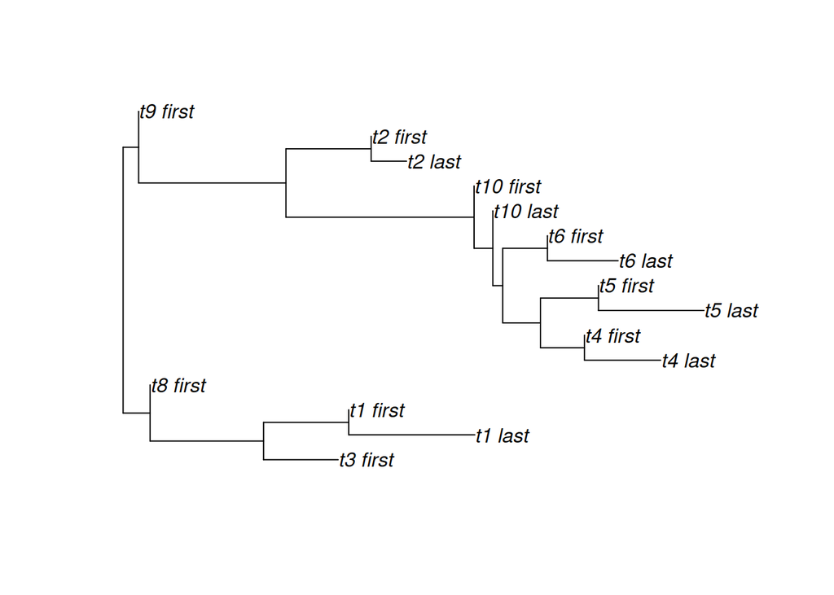

```r
SAt_pruned = prune.fossils(tree = SAt$tree)
plot(SAt_pruned)
```

`sampled.tree.from.combined` removes all unsampled lineages from the tree, and can optionally apply a sampling probability to extant samples, or keep only a specified list of extant samples.

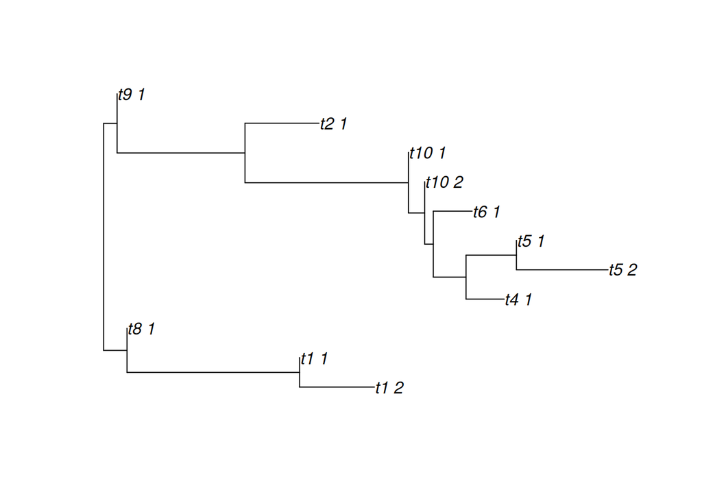

```r
SAt_sampled = sampled.tree.from.combined(tree = SAt$tree)
plot(SAt_sampled)
```

These two functions can be applied to any object of type `phylo`, but are designed to work on trees which include fossil samples.